# Prediction Assignment - Practical Machine Learning

Utsav Bali

14 August 2016

## Assignment introduction

Using devices such as Jawbone Up, Nike FuelBand, and Fitbit it is now possible to collect a large amount of data about personal activity relatively inexpensively. These type of devices are part of the quantified self movement – a group of enthusiasts who take measurements about themselves regularly to improve their health, to find patterns in their behavior, or because they are tech geeks. One thing that people regularly do is quantify how much of a particular activity they do, but they rarely quantify how well they do it.

## Objective

In this project, our goal is to use data from accelerometers on the belt, forearm, arm, and dumbell of 6 participants and predict the manner in which they did the exercise. This is the “classe” variable in the training set. We may use any of the other variables to predict with. Participants were asked to perform barbell lifts correctly and incorrectly in 5 different ways.The details are available from the website here: http://groupware.les.inf.puc-rio.br/har (see the section on the Weight Lifting Exercise Dataset).

## Data source

The training data for this project are available here: https://d396qusza40orc.cloudfront.net/predmachlearn/pml-training.csv

The test data are available here: https://d396qusza40orc.cloudfront.net/predmachlearn/pml-testing.csv

The data for this project come from this source: http://groupware.les.inf.puc-rio.br/har.

## Load packages

Loading the required packages for downstream analysis…

```r
library(dplyr)
```

```r
library(ggplot2)
library(AppliedPredictiveModeling)
library(caret)
library(rattle)
library(rpart.plot)
library(randomForest)
```

## Loading data

We shall load the data as follows:

```r
# set working director
setwd("~/datasciencecoursera/Programming_Assignment/Practical_Machine_Learning/Project")

# download files
if (!file.exists("pml-training.csv")) {
        download.file("http://d396qusza40orc.cloudfront.net/predmachlearn/pml-training.csv", destfile = "pml-training.csv")
}
if (!file.exists("pml-testing.csv")) {
        download.file("http://d396qusza40orc.cloudfront.net/predmachlearn/pml-testing.csv", destfile = "pml-testing.csv")
}
```

Let’s read the files…

```r
# label the files as pmltest and pmltrain sets respectively
pmltest <- read.csv("pml-testing.csv", sep = ",", na.strings = c("", "NA"))
pmltrain <- read.csv("pml-training.csv", sep = ",", na.strings = c("", "NA"))
```

Let’s combine the two datasets and have a quick look at the structure

```r
# we use the 'bind_rows' function here instead of the 'rbind' function in case there are any missing variables between the dataset
complete_dataset <- bind_rows(pmltest, pmltrain)
 # check data
str(complete_dataset)
```

```
## 'data.frame':    19642 obs. of  161 variables:
##  $ X                       : int  1 2 3 4 5 6 7 8 9 10 ...
##  $ user_name               : Factor w/ 6 levels "adelmo","carlitos",..: 6 5 5 1 4 5 5 5 2 3 ...
##  $ raw_timestamp_part_1    : int  1323095002 1322673067 1322673075 1322832789 1322489635 1322673149 1322673128 1322673076 1323084240 1322837822 ...
##  $ raw_timestamp_part_2    : int  868349 778725 342967 560311 814776 510661 766645 54671 916313 384285 ...
##  $ cvtd_timestamp          : chr  "05/12/2011 14:23" "30/11/2011 17:11" "30/11/2011 17:11" "02/12/2011 13:33" ...
##  $ new_window              : chr  "no" "no" "no" "no" ...
##  $ num_window              : int  74 431 439 194 235 504 485 440 323 664 ...
##  $ roll_belt               : num  123 1.02 0.87 125 1.35 -5.92 1.2 0.43 0.93 114 ...
##  $ pitch_belt              : num  27 4.87 1.82 -41.6 3.33 1.59 4.44 4.15 6.72 22.4 ...
##  $ yaw_belt                : num  -4.75 -88.9 -88.5 162 -88.6 -87.7 -87.3 -88.5 -93.7 -13.1 ...
##  $ total_accel_belt        : int  20 4 5 17 3 4 4 4 4 18 ...
##  $ kurtosis_roll_belt      : Factor w/ 396 levels "-0.016850","-0.021024",..: NA NA NA NA NA NA NA NA NA NA ...
##  $ kurtosis_picth_belt     : Factor w/ 316 levels "-0.021887","-0.060755",..: NA NA NA NA NA NA NA NA NA NA ...
##  $ kurtosis_yaw_belt       : Factor w/ 1 level "#DIV/0!": NA NA NA NA NA NA NA NA NA NA ...
```

[output cut: 86 more lines]

It is apparent that there are a number of variables with missing values in the dataset which will be removed prior to model construction

## Data partitioning

The pmltrain data set shall be split into a training and test partition. Cross validation shall be performed with the ‘train’ partition and out of sample test shall be performed with the ‘test’ partition.

```r
set.seed(12345)
train_partition <- createDataPartition(y = pmltrain$classe, p = 0.7, list = FALSE)
train <- pmltrain[train_partition, ]
test <- pmltrain[-train_partition, ]
```

Let’s have a quick look at the data dimensions:

```r
rbind("train dataset" = dim(train), "test dataset" = dim(test))
```

```
##                [,1] [,2]
## train dataset 13737  160
## test dataset   5885  160
```

## Data cleanup

As we have seen previously, there are a number of variables in the dataset that contain ‘NA’ values such that we do not wish to preprocess the data using ’k nearest neighbors (knn) imputation. Our first order of business is to identify the features (variables) in the data set that contain NAs, near zero variates and subject identifiers that are not required for model building.

```r
# remove variables that contain greater than 95% NA values
NA_values <- sapply(train, function(x) mean(is.na(x))) > 0.95
# how many columns contain greater than 95% NA values
length(which(NA_values == TRUE))
```

```
## [1] 100
```

```r
# filter the dataset to exclude column headers containing > 95% NAs
train <- train[, NA_values == F]
test <- test[, NA_values == F]
rbind("train dataset" = dim(train), "test dataset" = dim(test))
```

```
##                [,1] [,2]
## train dataset 13737   60
## test dataset   5885   60
```

We have now eliminated 100 columns from this data set with only 60 remaining to build a model from. We shall now attempt to remove variable that contain limited variability within them.

```r
# remove variables with nearly zero variance
nzv_values <- nearZeroVar(train)
train <- train[, -nzv_values]
test <- test[, -nzv_values]
rbind("train dataset" = dim(train), "test dataset" = dim(test))
```

```
##                [,1] [,2]
## train dataset 13737   59
## test dataset   5885   59
```

```r
# we have also removed column 6 as a result of this operation
```

Let’s now remove columns (variables) that are identifiers and will not be required for building our model. These would include the first five columns (X, user_name, raw_timestamp_part_1, raw_timestamp_part2, cvtd_timestamp).

```r
# remove columns 1-5
train <- train[, -(1:5)]
test <- test[, -(1:5)]
rbind("train dataset" = dim(train), "test dataset" = dim(test))
```

```
##                [,1] [,2]
## train dataset 13737   54
## test dataset   5885   54
```

In addition, to the now 54 columns, we can further exclude variables that are highly correlated.

```r
# identify the `classe` column index
classe_index <- which(names(train) == "classe")

# find correlation between all columns except the 'classe' variable and output index for all correlations > 90
correlation_index <- findCorrelation(abs(cor(train[,-classe_index])),0.90)

# names of columns with high correlation
correlation_names <- names(train)[correlation_index]
```

These are the columns that are highly correlated:

```r
correlation_names
```

```
## [1] "accel_belt_z"     "roll_belt"        "accel_belt_y"
## [4] "accel_belt_x"     "gyros_dumbbell_x" "gyros_dumbbell_z"
## [7] "gyros_arm_x"
```

Let’s further refine the train and the test partitions with the highly correlated columns removed.

```r
train <- train[,-correlation_index]
test <- test[, -correlation_index]
rbind("train dataset" = dim(train), "test dataset" = dim(test))
```

```
##                [,1] [,2]
## train dataset 13737   47
## test dataset   5885   47
```

```r
classe_index <- which(names(train) == "classe")
```

## Feature importance using random forest

We have now further removed 7 variables from this dataset. Let’s now use random forest to identify the most important features

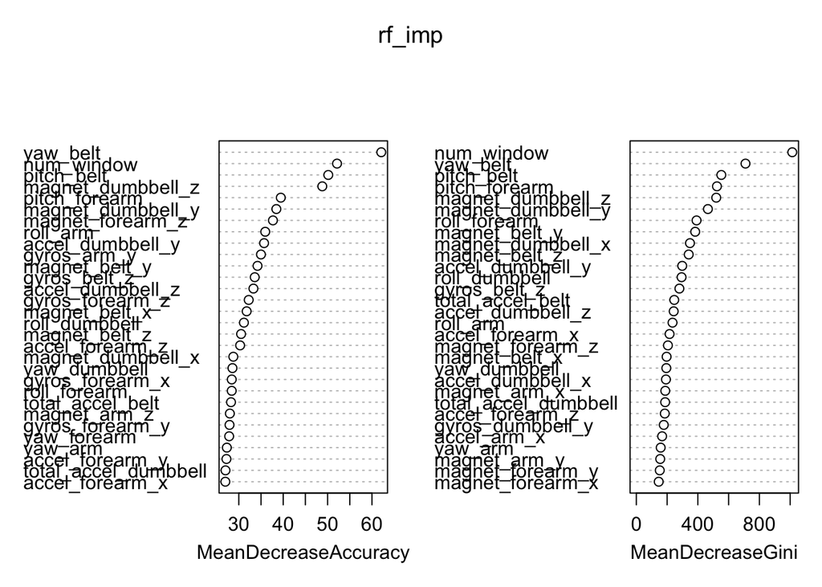

```r
# we'll set the argument 'importance = T'
rf_imp <- randomForest(train[, -classe_index], train[, classe_index], importance = T)

varImpPlot(rf_imp)
```

```r
# the plots show how much a decrease in accuracy would be expected if we remove each of the predictors and the second plot shows the same for Gini index

# let's show the table containing feature importance
# varImp(rf_imp)
rf_imp$importance
```

```
##                                A           B           C           D
## num_window           0.132157393 0.174942246 0.246393089 0.171952450
## pitch_belt           0.084712215 0.133327219 0.117759529 0.133570367
## yaw_belt             0.116528948 0.111133347 0.146273111 0.192240550
## total_accel_belt     0.023333114 0.030591507 0.039290780 0.034486397
## gyros_belt_x         0.017432432 0.012864354 0.027542941 0.015809197
## gyros_belt_y         0.012595982 0.020698245 0.027113252 0.022404993
## gyros_belt_z         0.031482046 0.047096179 0.059571419 0.050966140
## magnet_belt_x        0.024364873 0.037867204 0.049623876 0.040754772
## magnet_belt_y        0.045805529 0.070196021 0.067605622 0.078512133
## magnet_belt_z        0.049579215 0.072104808 0.075791704 0.088377000
## roll_arm             0.027064079 0.041750997 0.054817502 0.070188939
## pitch_arm            0.015696259 0.020917939 0.020226597 0.019850105
## yaw_arm              0.019814856 0.019788032 0.024437167 0.030574707
## total_accel_arm      0.009332575 0.008540426 0.010357571 0.014927748
## gyros_arm_y          0.013875269 0.016251451 0.007746071 0.013972440
## gyros_arm_z          0.005312605 0.005135516 0.004688202 0.005492142
## accel_arm_x          0.036321602 0.029350851 0.031273328 0.050297048
## accel_arm_y          0.015938977 0.020632599 0.019241075 0.021825897
## accel_arm_z          0.018997846 0.012430049 0.018782966 0.011580207
## magnet_arm_x         0.056069633 0.040945425 0.043302052 0.065546630
## magnet_arm_y         0.025761749 0.034902657 0.036857194 0.048848279
## magnet_arm_z         0.019345892 0.022681396 0.021035355 0.016377193
## roll_dumbbell        0.034883424 0.070110174 0.108974237 0.072548968
## pitch_dumbbell       0.018332852 0.028348071 0.040350295 0.033334986
## yaw_dumbbell         0.032772937 0.038899114 0.067261637 0.045080621
## total_accel_dumbbell 0.036035514 0.029688315 0.044503765 0.055136001
## gyros_dumbbell_y     0.021031427 0.025418523 0.044213826 0.027902089
## accel_dumbbell_x     0.033204266 0.037273618 0.061782592 0.048493245
## accel_dumbbell_y     0.044589284 0.056118602 0.110308644 0.069847024
## accel_dumbbell_z     0.040688268 0.046281960 0.073625299 0.059597331
## magnet_dumbbell_x    0.101946667 0.081082417 0.145743826 0.112137076
## magnet_dumbbell_y    0.091979996 0.116382333 0.165413055 0.143645968
## magnet_dumbbell_z    0.115035858 0.095828430 0.139140622 0.115436163
## roll_forearm         0.114061347 0.083801123 0.167932517 0.105491293
## pitch_forearm        0.086439521 0.057673453 0.077784914 0.126243330
## yaw_forearm          0.014422411 0.016367979 0.023614436 0.033631722
## total_accel_forearm  0.011900715 0.007388270 0.009607769 0.009007274
## gyros_forearm_x      0.003188010 0.006896706 0.008921579 0.012669005
## gyros_forearm_y      0.007404304 0.013471260 0.008447200 0.010627412
```

[output cut: 39 more lines]

```
## magnet_dumbbell_y    0.068939582          0.113711064        465.22781
## magnet_dumbbell_z    0.064227147          0.106251884        519.44243
## roll_forearm         0.065121747          0.107223635        391.46019
## pitch_forearm        0.054645582          0.080052426        524.14780
## yaw_forearm          0.012499412          0.019200389        111.15516
## total_accel_forearm  0.005007998          0.008890655         71.09659
## gyros_forearm_x      0.004665491          0.006729720         58.18558
## gyros_forearm_y      0.006918627          0.009197672         90.55361
## gyros_forearm_z      0.002950997          0.004963941         55.95722
## accel_forearm_x      0.037925985          0.043723528        216.05636
## accel_forearm_y      0.009561067          0.016217611         96.10769
## accel_forearm_z      0.026708051          0.034401385        184.93609
## magnet_forearm_x     0.020647427          0.022484841        145.47454
## magnet_forearm_y     0.018649153          0.024253658        152.30058
## magnet_forearm_z     0.023401833          0.030706340        205.32047
```

## Model building

We shall attempt to examine the cleaned data set using three algorithms and evaluate their ‘out of sample’ accuracy to find the best model. We’ll fit the model with - * Decision trees with CART (rpart) * Stochastic gradient boosting trees(gbm) and * Random forest decision trees (rf)

First to fit the data to CART -

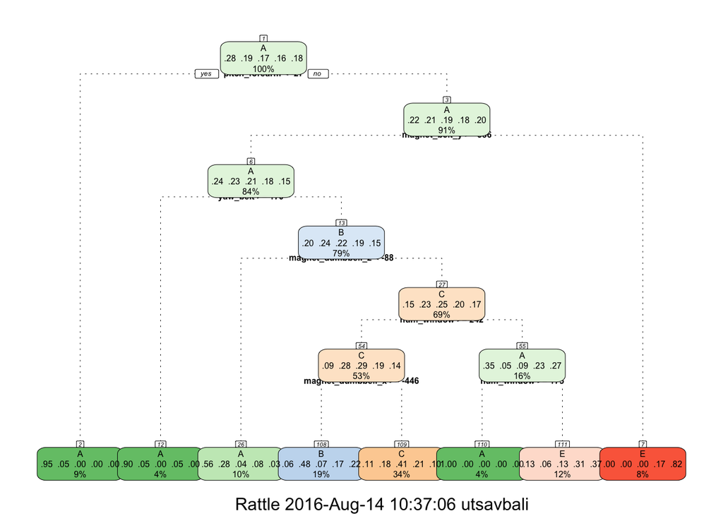

```r
#  method 'cv' in the train function in the caret package breaks the data set train into k-folds (defaulted),
# and then starts over and runs it 3 times
cross_validation <- trainControl(method = "cv", number=3, repeats=3)

cart_model <- train(classe ~ ., data = train, trControl = cross_validation, method = 'rpart')

#plot the decision tree using rattle package
fancyRpartPlot(cart_model$finalModel,cex=.5,under.cex=1,shadow.offset=0)
```

Next we’ll fit the data to Stochastic Gradient Boosting (gbm) -

```r
gbm_model <- train(classe ~ ., data = train, trControl = cross_validation, method='gbm')
```

And also fit to random forest -

```r
rf_model <- train(classe ~., data = train, trControl = cross_validation, method = 'rf', ntree = 100)
# List of 20 most important variables
varImp(rf_model)
```

```
## rf variable importance
##
##   only 20 most important variables shown (out of 46)
##
##                      Overall
## num_window           100.000
## yaw_belt              44.366
## pitch_forearm         40.272
## magnet_dumbbell_z     29.704
## pitch_belt            29.604
## magnet_dumbbell_y     26.563
## roll_forearm          20.722
## magnet_belt_y         20.543
## accel_dumbbell_y      12.706
## roll_dumbbell         11.573
## magnet_dumbbell_x     11.522
## total_accel_belt      10.776
## magnet_belt_z         10.535
## accel_forearm_x        9.839
## gyros_belt_z           9.397
## total_accel_dumbbell   7.924
## magnet_belt_x          7.805
## accel_forearm_z        7.805
## accel_dumbbell_z       7.293
## magnet_forearm_z       6.551
```

## Prediction with test data and calculation of Out Of Sample error

```r
# prediction of test data using 'cart_model'
CART_prediction <- predict(cart_model, newdata = test)
CART_confusion_matrix <- confusionMatrix(CART_prediction, test$classe)

# prediction of test data using 'gbm_model'
GBM_prediction <- predict(gbm_model, newdata = test)
GBM_confusion_matrix <- confusionMatrix(GBM_prediction, test$classe)

# prediction of test data using 'rf_model'
RF_prediction <- predict(rf_model, newdata = test)
RF_confusion_matrix <- confusionMatrix(RF_prediction, test$classe)

# report accuracy from each model on the test data
model_accuracy <- data.frame(Model = c('CART', 'GBM', 'RF'), Accuracy = rbind(CART_confusion_matrix$overall[1], GBM_confusion_matrix$overall[1], RF_confusion_matrix$overall[1]))
print(model_accuracy)
```

```
##   Model  Accuracy
## 1  CART 0.5638063
## 2   GBM 0.9828377
## 3    RF 0.9966015
```

The above analysis using the 3 model fits shows that both the gbm and the rf are better than the CART model. The random forest model is the most accurate with the following confusion matrix -

```r
RF_confusion_matrix
```

```
## Confusion Matrix and Statistics
##
##           Reference
## Prediction    A    B    C    D    E
##          A 1674    5    0    0    0
##          B    0 1132    2    0    0
##          C    0    2 1024    8    0
##          D    0    0    0  956    3
##          E    0    0    0    0 1079
##
## Overall Statistics
##
##                Accuracy : 0.9966
##                  95% CI : (0.9948, 0.9979)
##     No Information Rate : 0.2845
##     P-Value [Acc > NIR] : < 2.2e-16
##
##                   Kappa : 0.9957
##  Mcnemar's Test P-Value : NA
##
## Statistics by Class:
##
##                      Class: A Class: B Class: C Class: D Class: E
## Sensitivity            1.0000   0.9939   0.9981   0.9917   0.9972
## Specificity            0.9988   0.9996   0.9979   0.9994   1.0000
## Pos Pred Value         0.9970   0.9982   0.9903   0.9969   1.0000
## Neg Pred Value         1.0000   0.9985   0.9996   0.9984   0.9994
## Prevalence             0.2845   0.1935   0.1743   0.1638   0.1839
## Detection Rate         0.2845   0.1924   0.1740   0.1624   0.1833
## Detection Prevalence   0.2853   0.1927   0.1757   0.1630   0.1833
## Balanced Accuracy      0.9994   0.9967   0.9980   0.9955   0.9986
```

```r
# varImp(rf_model)
```

## Prediction

Due to the high accuracy observed with the rf model, we shall use this model to predict the data in the ‘pml-testing.csv’ file to predict a classe for each of the 20 observations.

```r
prediction <- predict(rf_model, newdata = pmltest)
pml_test_results <- data.frame(problem_id = pmltest$problem_id, predicted = prediction)
```

## Conclusion

```r
print(pml_test_results)
```

```
##    problem_id predicted
## 1           1         B
## 2           2         A
## 3           3         B
## 4           4         A
## 5           5         A
## 6           6         E
## 7           7         D
## 8           8         B
## 9           9         A
## 10         10         A
## 11         11         B
## 12         12         C
## 13         13         B
## 14         14         A
## 15         15         E
## 16         16         E
## 17         17         A
## 18         18         B
## 19         19         B
## 20         20         B
```